# exFINDER predicts the roles of external signals and uncovers transition paths in differentiation

# Part IV: Find critical transition signal-related signaling network

The transcription factors that regulate critical transition are denoted as critical transition signals (CTS), here we perform exFINDER analysis to infer the exSigNet that associated to the CTS.

## Infer the CTS-related signaling network

```r
# setup target genes
marker.1 <- read.csv(file = "../markers/Faure2020_Mouse_marker/Faure2020_Mouse_markers_INCCs.csv")
marker.2 <- read.csv(file = "../markers/Faure2020_Mouse_marker/Faure2020_Mouse_markers_unassigned.1.csv")
marker.3 <- read.csv(file = "../markers/Faure2020_Mouse_marker/Faure2020_Mouse_markers_INCCs.BCCs.csv")

marker.1 <- marker.1$X[1:10]
marker.2 <- marker.2$X[1:10]
marker.3 <- marker.3$X[1:10]
target.123 <- c(marker.1, marker.2, marker.3)
```

```r
# infer ltGRN
ltGRN <- get_ltGRN(Target = target.123, DB = exFINDER.M)
```

```r
# infer potential external signals from ltGRN
Pex <- get_potentialex(Graph = ltGRN,
                Exp.Data = exp.data,
                Meta.Data = meta.data,
                cutoff = -0.05,
                AG.L = NULL)

# head(Pex.new)
```

```r
# infer exSigNet (R, TF, T are all highly expressed, L comes from the potential external signals)
# here, we are interested in the existance of the exSigNet that associated to the CTS, so we set the cutoff values to be relatively low
exSigNet <- get_exSigNet(Graph = ltGRN,
                       Ligands = Pex,
                       Exp.Data = exp.data,
                       Meta.Data = meta.data,
                       par.cutoff = c(0.05, 0.001),
                       AG.R = c("INCCs", "INCCs.BCCs", "unassigned.1"),
                       AG.TF = c("INCCs", "INCCs.BCCs", "unassigned.1"))
# exSigNet
```

```r
# fix the overlap issue
exSigNet <- fix_OverLap(exSigNet)
```

```
#> [1] "No overlap found!"
```

```r
# check if there is any CTS included in the inferred exSigNet
intersect(exSigNet$Graph.Node$Gene[exSigNet$Graph.Node$Role == "TF"], CTS_2)
```

```
#> [1] "Mitf"
```

```r
# based on the exSigNet, we infer its sub-Network by select the CTS
Path.Graph <- get_subNet(Graph = exSigNet,
           TF = "Mitf")
# Path.Graph
```

```r
# based on this "exSigNet.new", we identify the receptors that only activated by these external signals
Path.Graph <- filterLR_exSigNet(Graph = Path.Graph,
                  Exp.Data = exp.data,
                  DB = exFINDER.M)
```

```
#> [1] "No overlap found!"
```

```r
Path.Graph
```

```
#> $Graph.Edge
#>   from    to   source       path from.Role  to.Role
#> 1 Fpr3   App   IUPHAR   Fpr3*App    Ligand Receptor
#> 2 Fpr2   App   IUPHAR   Fpr2*App    Ligand Receptor
#> 3  App  Mitf NicheNet   App*Mitf  Receptor       TF
#> 4 Mitf Erbb3 NicheNet Mitf*Erbb3        TF   Target
#> 5 Mitf  Rxrg NicheNet  Mitf*Rxrg        TF   Target
#> 6 Mitf   Mpz NicheNet   Mitf*Mpz        TF   Target
#> 7 Mitf Myo5b NicheNet Mitf*Myo5b        TF   Target
#> 8 Mitf  Tgm2 NicheNet  Mitf*Tgm2        TF   Target
#> 9 Mitf Itgb3 NicheNet Mitf*Itgb3        TF   Target
#>
#> $Graph.Node
#>     Gene     Role
#> 1   Fpr3   Ligand
#> 2   Fpr2   Ligand
#> 3    App Receptor
#> 4   Mitf       TF
#> 5  Erbb3   Target
#> 6   Rxrg   Target
#> 7    Mpz   Target
#> 8  Myo5b   Target
#> 9   Tgm2   Target
#> 10 Itgb3   Target
```

```r
Path.Graph <- get_NodeValue(Graph = Path.Graph,
                          Exp.Data = exp.data,
                          Meta.Data = meta.data,
                          AG.R = c("INCCs", "INCCs.BCCs", "Nociceptive"),
                          AG.TF = c("INCCs.BCCs", "Nociceptive"),
                          AG.T = c("INCCs.BCCs", "Nociceptive"),
                          Exp.ExData = NULL,
                          Meta.ExData = NULL,
                          AG.ExData = NULL)

Path.Graph <- get_EdgeWeight(Graph = Path.Graph,
               Kh = 2)

Path.Graph
```

```
#> $Graph.Edge
#>   from    to   source       path from.Role  to.Role       Weight
#> 1 Fpr3   App   IUPHAR   Fpr3*App    Ligand Receptor 0.4149111469
#> 2 Fpr2   App   IUPHAR   Fpr2*App    Ligand Receptor 0.4149111469
#> 3  App  Mitf NicheNet   App*Mitf  Receptor       TF 0.0156509540
#> 4 Mitf Erbb3 NicheNet Mitf*Erbb3        TF   Target 0.0095334066
#> 5 Mitf  Rxrg NicheNet  Mitf*Rxrg        TF   Target 0.0077192274
#> 6 Mitf   Mpz NicheNet   Mitf*Mpz        TF   Target 0.0104967354
#> 7 Mitf Myo5b NicheNet Mitf*Myo5b        TF   Target 0.0025813598
#> 8 Mitf  Tgm2 NicheNet  Mitf*Tgm2        TF   Target 0.0005650586
#> 9 Mitf Itgb3 NicheNet Mitf*Itgb3        TF   Target 0.0033910469
#>
#> $Graph.Node
#>     Gene     Role       Size
#> 1   Fpr3   Ligand 1.00000000
#> 2   Fpr2   Ligand 1.00000000
#> 3    App Receptor 1.41828423
#> 4   Mitf       TF 0.02242118
#> 5  Erbb3   Target 0.85857822
#> 6   Rxrg   Target 0.69392230
#> 7    Mpz   Target 0.94625590
#> 8  Myo5b   Target 0.23085679
#> 9   Tgm2   Target 0.05043251
#> 10 Itgb3   Target 0.30351530
```

## Visualize the network

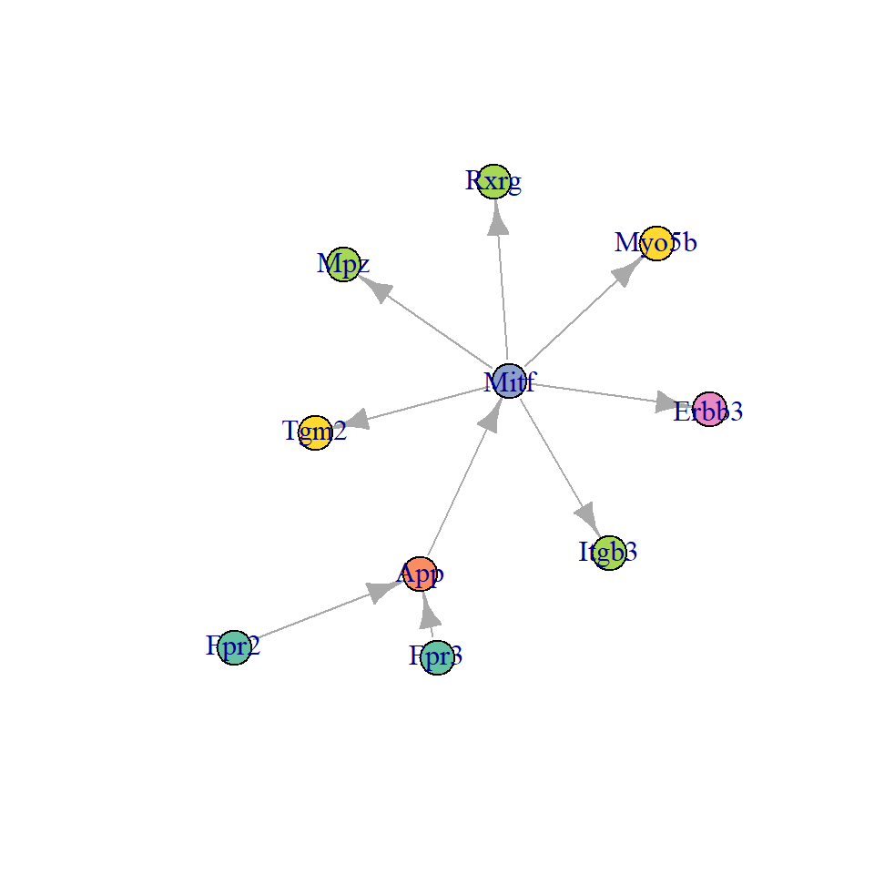

```r
library(igraph)
# customize the label for coloring
Path.Graph$Graph.Node$Role[Path.Graph$Graph.Node$Gene == "Erbb3"] = "Target (INCCs)"
Path.Graph$Graph.Node$Role[Path.Graph$Graph.Node$Gene %in% c("Rxrg", "Mpz", "Itgb3")] = "Target (INCCs.BCCs)"
Path.Graph$Graph.Node$Role[Path.Graph$Graph.Node$Gene %in% c("Myo5b", "Tgm2")] = "Target (unassigned.1)"

actors <- data.frame(
  name = Path.Graph$Graph.Node$Gene,
  role = Path.Graph$Graph.Node$Role
)

relations <- data.frame(
  from = Path.Graph$Graph.Edge$from,
  to = Path.Graph$Graph.Edge$to
)

g <- graph_from_data_frame(
  relations, directed = TRUE,
  vertices = actors
)

l <- layout_with_lgl(g)

library(RColorBrewer)
coul  <- brewer.pal(6, "Set2")
# Create a vector of color
my_color <- coul[as.numeric(as.factor(V(g)$role))]

plot(g, layout=l, vertex.color=my_color)
```

# Part V: infer exSigNet targeting INCCs

## Infer the exSigNet

```r
# target genes
marker.1 <- read.csv(file = "../markers/Faure2020_Mouse_marker/Faure2020_Mouse_markers_INCCs.csv")
target.1 <- marker.1$X[1:10]
```

```r
# infer ltGRN
ltGRN.2 <- get_ltGRN(Target = target.1, DB = exFINDER.M)
```

```r
# infer potential external signals from ltGRN
Pex.2 <- get_potentialex(Graph = ltGRN.2,
                Exp.Data = exp.data,
                Meta.Data = meta.data,
                cutoff = -0.05,
                AG.L = NULL)

# head(Pex.new)
```

```r
# infer exSigNet (R, TF, T are all highly expressed, L comes from the potential external signals)
exSigNet.2 <- get_exSigNet(Graph = ltGRN.2,
                       Ligands = Pex.2,
                       Exp.Data = exp.data,
                       Meta.Data = meta.data,
                       par.cutoff = c(0.8, 1.5),
                       AG.R = c("INCCs"),
                       AG.TF = c("INCCs"))
# exSigNet.new
```

```r
# based on this "exSigNet.new", we identify the receptors that only activated by these external signals
exSigNet.2 <- filterLR_exSigNet(Graph = exSigNet.2,
                  Exp.Data = exp.data,
                  DB = exFINDER.M)
```

```
#> [1] "No overlap found!"
```

```r
exSigNet.2
```

```
#> $Graph.Edge
#>     from     to             source         path from.Role  to.Role
#> 1   Fgf2   Glg1           NicheNet    Fgf2*Glg1    Ligand Receptor
#> 2   Sele   Glg1 NicheNet, CellChat    Sele*Glg1    Ligand Receptor
#> 3   Pld2   Arf1             IUPHAR    Pld2*Arf1    Ligand Receptor
#> 4   Arf1   Chd4           NicheNet    Arf1*Chd4  Receptor       TF
#> 5   Glg1    Sf1           NicheNet     Glg1*Sf1  Receptor       TF
#> 6   Arf1  Pcbp1           NicheNet   Arf1*Pcbp1  Receptor       TF
#> 7   Arf1  Pa2g4           NicheNet   Arf1*Pa2g4  Receptor       TF
#> 8   Arf1  Hcfc1           NicheNet   Arf1*Hcfc1  Receptor       TF
#> 9  Hcfc1  Erbb3           NicheNet  Hcfc1*Erbb3        TF   Target
#> 10  Chd4  Erbb3           NicheNet   Chd4*Erbb3        TF   Target
#> 11 Pa2g4  Erbb3           NicheNet  Pa2g4*Erbb3        TF   Target
#> 12   Sf1 Hoxd10           NicheNet   Sf1*Hoxd10        TF   Target
#> 13 Pcbp1 Hoxd10           NicheNet Pcbp1*Hoxd10        TF   Target
```

[output cut: 29 more lines]

```r
exSigNet.2 <- get_NodeValue(Graph = exSigNet.2,
                          Exp.Data = exp.data,
                          Meta.Data = meta.data,
                          AG.R = c("INCCs"),
                          AG.TF = c("INCCs"),
                          AG.T = c("INCCs"),
                          Exp.ExData = NULL,
                          Meta.ExData = NULL,
                          AG.ExData = NULL)

exSigNet.2 <- get_EdgeWeight(Graph = exSigNet.2,
               Kh = 2)

exSigNet.2
```

```
#> $Graph.Edge
#>     from     to             source         path from.Role  to.Role    Weight
#> 1   Fgf2   Glg1           NicheNet    Fgf2*Glg1    Ligand Receptor 0.3329120
#> 2   Sele   Glg1 NicheNet, CellChat    Sele*Glg1    Ligand Receptor 0.3329120
#> 3   Pld2   Arf1             IUPHAR    Pld2*Arf1    Ligand Receptor 0.4066939
#> 4   Arf1   Chd4           NicheNet    Arf1*Chd4  Receptor       TF 0.5271401
#> 5   Glg1    Sf1           NicheNet     Glg1*Sf1  Receptor       TF 0.4332012
#> 6   Arf1  Pcbp1           NicheNet   Arf1*Pcbp1  Receptor       TF 0.5537293
#> 7   Arf1  Pa2g4           NicheNet   Arf1*Pa2g4  Receptor       TF 0.5760697
#> 8   Arf1  Hcfc1           NicheNet   Arf1*Hcfc1  Receptor       TF 0.5429748
#> 9  Hcfc1  Erbb3           NicheNet  Hcfc1*Erbb3        TF   Target 0.5369984
#> 10  Chd4  Erbb3           NicheNet   Chd4*Erbb3        TF   Target 0.5211393
#> 11 Pa2g4  Erbb3           NicheNet  Pa2g4*Erbb3        TF   Target 0.5701835
#> 12   Sf1 Hoxd10           NicheNet   Sf1*Hoxd10        TF   Target 0.2431580
#> 13 Pcbp1 Hoxd10           NicheNet Pcbp1*Hoxd10        TF   Target 0.2752226
```

[output cut: 29 more lines]

## Predict critical external signals and targets

```r
# compute and compare the L-R maxflow
df <- get_LRMaxFlow(exSigNet.2)
df.TotalFlow <- compare_MaxFlow(df = df)
df.TotalFlow
```

```
#>      Gene TotalFlow   Role
#> 1    Fgf2 0.8433752 Ligand
#> 2    Pld2 2.6009163 Ligand
#> 3    Sele 0.8433752 Ligand
#> 4   Ajuba 0.4066939 Target
#> 5   Erbb3 0.4066939 Target
#> 6    Gas1 1.0725180 Target
#> 7  Hoxa10 0.4066939 Target
#> 8  Hoxc10 0.8268347 Target
#> 9  Hoxd10 0.7615385 Target
#> 10  Plcg2 0.4066939 Target
```

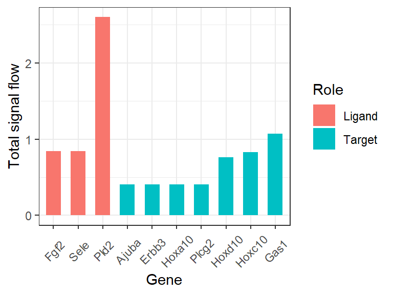

```r
# bar plot of the signal comparing results
df.TotalFlow %>%
  mutate(Gene = fct_reorder(Gene, TotalFlow* (Role=='Ligand'))) %>%
  mutate(Gene = fct_reorder(Gene, TotalFlow* (Role=='Target'))) %>%
  # mutate(Gene = fct_reorder(Gene, SI* (Type=='Full network'))) %>%
  ggplot(aes(x=Gene, y=TotalFlow,  fill=Role)) +
    geom_bar(stat="identity", alpha=1, width=.6) +
    xlab("Gene") +
    ylab("Total signal flow") +
    theme_bw() +
    theme(axis.text.x = element_text(angle = 45, hjust = 0.5, vjust = 0.5))
```

## Visualize the exSigNet

Heatmap plot

```r
# calculate the ave.exp for all genes of the exSigNet.2
exS.2_exp <- get_AveExp(Gene = exSigNet.2$Graph.Node$Gene,
           Exp.Data = exp.data,
           Meta.Data = meta.data)

# prepare the dataframe for heatmap plot
exS.2_exp.HP <- exS.2_exp
exS.2_exp.HP <- exS.2_exp.HP[, -1]
row.names(exS.2_exp.HP) <- exS.2_exp$Gene
exS.2_exp.HP
```

```
#>               INCCs unassigned.2  INCCs.BCCs  Nociceptive unassigned.1
#> Fgf2   0.0004102798 0.0005227462 0.001768187 0.0000000000 0.0005472132
#> Sele   0.0011718770 0.0001325638 0.001956391 0.0000000000 0.0001278181
#> Pld2   0.0214016967 0.0100945449 0.047005530 0.0128906877 0.0032418923
#> Glg1   0.9981053680 0.9266374898 0.799182091 0.7680694200 0.9762393539
#> Arf1   1.3709411480 1.4132059187 1.370823180 1.4966929854 1.4105309662
#> Chd4   1.6263153497 2.0527466983 1.164024464 1.4773452455 1.7874311910
#> Sf1    1.5314904084 0.8903005562 1.296201129 1.0586149996 1.5051320096
#> Pcbp1  1.8101324612 1.2739552582 1.806862292 1.6586582573 1.7599620482
#> Pa2g4  1.9824020706 0.9591726918 1.602598742 1.2117062595 1.6611259211
#> Hcfc1  1.7332077831 1.2501653659 1.322934080 1.3565013137 1.5905480730
#> Erbb3  1.3383502770 0.0006551082 0.858578224 0.0032160835 0.1100305324
#> Hoxd10 0.4195647378 0.0059682686 0.001671716 0.0000000000 0.1716919762
#> Ajuba  0.8907767239 0.0069489313 0.347597504 0.0187183435 0.2118523111
#> Gas1   1.3724627488 0.1182574764 0.563061703 0.1445506638 0.4256737804
#> Hoxc10 0.4764309898 0.0030278855 0.001127210 0.0001758058 0.3598787964
#> Plcg2  1.0915605778 0.0021106928 0.059119948 0.0017249831 0.1034813996
#> Hoxa10 0.4824804999 0.0067339822 0.004572806 0.0025515926 0.3868776482
```

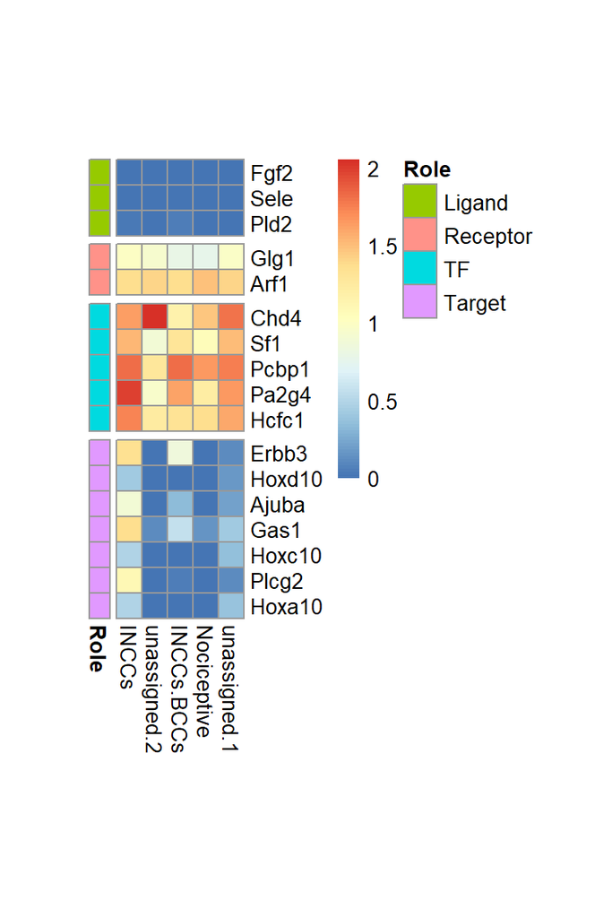

```r
# heatmap plot
annotation_row <- data.frame(Role = exSigNet.2$Graph.Node$Role)
row.names(annotation_row) <- row.names(exS.2_exp.HP)

pheatmap(exS.2_exp.HP,
        cluster_row = FALSE, cluster_cols = FALSE,
        cellwidth = 12, cellheight = 12,
        gaps_row = c(3, 5, 10),
        fontsize_row = 10,
        fontsize_col = 10,
        annotation_row = annotation_row)
```

hierarchy plot

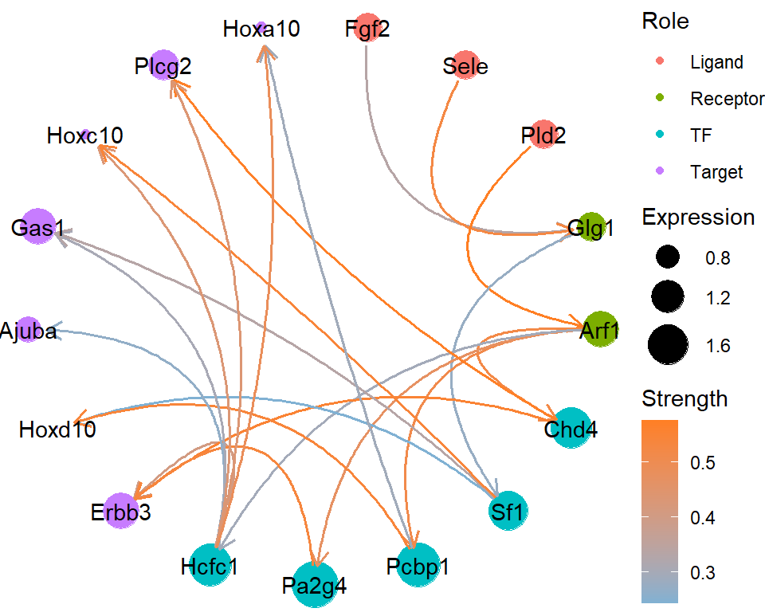

```r
# hierarchy plot
exSigNet.2_plot <- get_readyforplot(Graph = exSigNet.2)

ggraph(exSigNet.2_plot[[1]], layout = 'dendrogram', circular = TRUE) +
  geom_node_point(aes(filter = leaf, x=x, y=y, colour=Role, size=Expression)) +
  theme_void() +
  geom_conn_bundle(data = get_con(from = exSigNet.2_plot[[2]]$from,
                                  to = exSigNet.2_plot[[2]]$to,
                                  Strength = exSigNet.2_plot[[2]]$weight), width = 0.7, aes(colour=Strength),
                   arrow = arrow(length = unit(3, 'mm')), start_cap = circle(3, 'mm'), end_cap = circle(3, 'mm')) +
  scale_edge_color_continuous(low="#80b1d3", high="#FF7F24")+
  geom_node_text(aes(label = node)) +
  scale_size_continuous( range = c(0.1,10) )
```

## Evaluate the GO analysis

```r
library(org.Mm.eg.db)
# library(org.Dr.eg.db)
# library(org.Hs.eg.db)
```

```r
GO.exSigNet.2 <- get_EnrichAnalysis(Graph = exSigNet.2,
                               OrgDb = org.Mm.eg.db,
                               Number.of.Terms = 5,
                               ont = "BP",
                               pvalueCutoff = 0.05,
                               qvalueCutoff = 0.2)
GO.exSigNet.2
```

```
#> $`GO analysis results`
#> #
#> # over-representation test
#> #
#> #...@organism     Mus musculus
#> #...@ontology     BP
#> #...@keytype      ENTREZID
#> #...@gene     chr [1:17] "14173" "20339" "18806" "20340" "11840" "107932" "22668" ...
#> #...pvalues adjusted by 'BH' with cutoff <0.05
#> #...221 enriched terms found
#> 'data.frame':    221 obs. of  9 variables:
#>  $ ID         : chr  "GO:0048259" "GO:0045807" "GO:0031623" "GO:0030326" ...
#>  $ Description: chr  "regulation of receptor-mediated endocytosis" "positive regulation of endocytosis" "receptor internalization" "embryonic limb morphogenesis" ...
#>  $ GeneRatio  : chr  "4/17" "4/17" "4/17" "4/17" ...
#>  $ BgRatio    : chr  "126/29008" "128/29008" "136/29008" "143/29008" ...
#>  $ pvalue     : num  7.73e-07 8.23e-07 1.05e-06 1.28e-06 1.28e-06 ...
#>  $ p.adjust   : num  0.000176 0.000176 0.000176 0.000176 0.000176 ...
#>  $ qvalue     : num  7.88e-05 7.88e-05 7.88e-05 7.88e-05 7.88e-05 ...
#>  $ geneID     : chr  "20339/18806/11840/234779" "20339/18806/11840/234779" "20339/18806/11840/234779" "15430/14451/209448/15395" ...
#>  $ Count      : int  4 4 4 4 4 3 5 5 4 4 ...
#> #...Citation
#>  T Wu, E Hu, S Xu, M Chen, P Guo, Z Dai, T Feng, L Zhou, W Tang, L Zhan, X Fu, S Liu, X Bo, and G Yu.
#>  clusterProfiler 4.0: A universal enrichment tool for interpreting omics data.
#>  The Innovation. 2021, 2(3):100141
#>
#>
#> $Evaluation
#>             Node.Pct   Exp.Pct                                     GO.Name
#> GO:0048259 0.2352941 0.1366979 regulation of receptor-mediated endocytosis
#> GO:0045807 0.2352941 0.1366979          positive regulation of endocytosis
#> GO:0031623 0.2352941 0.2217478                    receptor internalization
#> GO:0030326 0.2352941 0.2217478                embryonic limb morphogenesis
#> GO:0035113 0.2352941 0.2217478           embryonic appendage morphogenesis
```

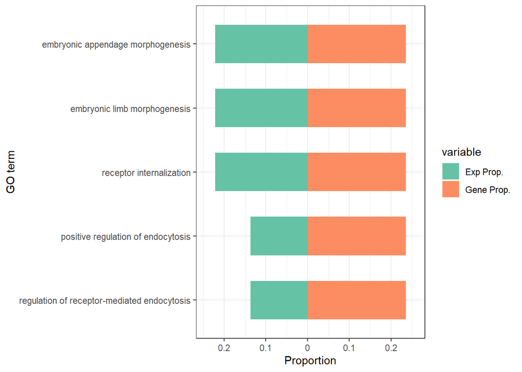

```r
# visualize the results
GO.df <- GO.exSigNet.2[[2]]

GO.df.1 <- data.frame(GO.term = rownames(GO.df), variable = "Gene Prop.", value = GO.df$Node.Pct, GO.name = GO.df$GO.Name)
GO.df.2 <- data.frame(GO.term = rownames(GO.df), variable = "Exp Prop.", value = GO.df$Exp.Pct, GO.name = GO.df$GO.Name)
GO.df.3 <- rbind(GO.df.1, GO.df.2)

ggplot(GO.df.3, aes(
                x = factor(GO.name, levels = unique(GO.name)),
                y = ifelse(variable == "Gene Prop.", value, -value),  fill = variable)) +
  geom_bar(stat = 'identity', width=0.6)+
  scale_fill_brewer(palette = 'Set2')+
  coord_flip()+
  scale_y_continuous(
    labels = abs,
    expand = expansion(mult = c(0.1, 0.1))) +
    ylab("Proportion") +
    xlab("GO term") +
    theme_bw()
```

# Part VI: Infer exSigNet that activating branch B

This part, we use exFINDER to investigate how the external signals activate Branch B (i.e. target the early divergent genes) through critical transcription factors. Both the early divergent genes and transcription factors are mentioned in the original paper: Faure, L., Wang, Y., Kastriti, M.E. et al. Single cell RNA sequencing identifies early diversity of sensory neurons forming via bi-potential intermediates. Nat Commun 11, 4175 (2020). https://doi.org/10.1038/s41467-020-17929-4

## Infer the exSigNet

```r
# set-up target genes
target.paper <- c("Dnase", "A330009N2", "Grasp", "Cdc42ep4", "Abracl", "Crybg3", "Slc29a1", "Msi2", "Nkain4")

# infer ltGRN
ltGRN.new <- get_ltGRN(Target = target.paper, DB = exFINDER.M)
```

```r
# identify potential external signals
Pex.new <- get_potentialex(Graph = ltGRN.new,
                Exp.Data = exp.data,
                Meta.Data = meta.data,
                cutoff = -0.05,
                AG.L = NULL)
               # AG.L = c("Nociceptive", "unassigned.1", "unassigned.2"))

# infer exSigNet
exSigNet.new <- get_exSigNet(Graph = ltGRN.new,
                       Ligands = Pex.new,
                       Exp.Data = exp.data,
                       Meta.Data = meta.data,
                       par.cutoff = c(0.25, 0.25),
                       AG.R = c("INCCs.BCCs", "INCCs", "unassigned.1"),
                       AG.TF = c("INCCs.BCCs", "unassigned.1", "Nociceptive"))
# select the TFs based on previous paper's results
exSigNet.new2 <- get_subNet(Graph = exSigNet.new,
           TF = c("Neurod2", "Nfib", "Hes6", "Tead1", "Foxp2", "Tfap2a", "Foxp4", "Ezh2", "Tcf4"))


exSigNet.new2 <- filterLR_exSigNet(Graph = exSigNet.new2,
                  Exp.Data = exp.data,
                  DB = exFINDER.M)
```

```
#> [1] "No overlap found!"
```

```r
exSigNet.new2
```

```
#> $Graph.Edge
#>      from       to   source            path from.Role  to.Role
#> 1  Ifna12   Ifnar1 NicheNet   Ifna12*Ifnar1    Ligand Receptor
#> 2   Ifna4   Ifnar1 NicheNet    Ifna4*Ifnar1    Ligand Receptor
#> 3  Ifna11   Ifnar1 NicheNet   Ifna11*Ifnar1    Ligand Receptor
#> 4  Ifna13   Ifnar1 NicheNet   Ifna13*Ifnar1    Ligand Receptor
#> 5   Ifna6   Ifnar1 NicheNet    Ifna6*Ifnar1    Ligand Receptor
#> 6   Ifna2   Ifnar1 NicheNet    Ifna2*Ifnar1    Ligand Receptor
#> 7   Ifna9   Ifnar1 NicheNet    Ifna9*Ifnar1    Ligand Receptor
#> 8   Ifna1   Ifnar1 NicheNet    Ifna1*Ifnar1    Ligand Receptor
#> 9   Ifna7   Ifnar1 NicheNet    Ifna7*Ifnar1    Ligand Receptor
#> 10 Ifna14   Ifnar1 NicheNet   Ifna14*Ifnar1    Ligand Receptor
#> 11  Ifna5   Ifnar1 NicheNet    Ifna5*Ifnar1    Ligand Receptor
#> 12  Ifnab   Ifnar1 NicheNet    Ifnab*Ifnar1    Ligand Receptor
#> 13   Ifnk   Ifnar1 NicheNet     Ifnk*Ifnar1    Ligand Receptor
```

[output cut: 48 more lines]

## Check the expression of receptors

```r
# check the receptors' expression levels in each cell group
R.BranchB <- exSigNet.new2$Graph.Node$Gene[exSigNet.new2$Graph.Node$Role == "Receptor"]

R.BranchB.df <- get_AveExp(Gene = R.BranchB,
           Exp.Data = exp.data,
           Meta.Data = meta.data)
R.BranchB.df
```

```
#>     Gene     INCCs unassigned.2 INCCs.BCCs Nociceptive unassigned.1
#> 1 Ifnar1 0.7324313   0.88662012  0.6901511  0.68487011   0.69001063
#> 2   Rarg 0.2089452   0.01317359  0.2620868  0.02509846   0.01876856
```

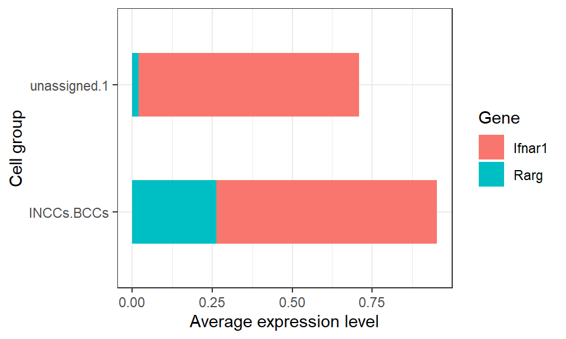

```r
# visualize the results
df <- data.frame(Exp = c(R.BranchB.df$INCCs.BCCs, R.BranchB.df$unassigned.1), Gene = c('Ifnar1', 'Rarg', 'Ifnar1', 'Rarg'),
                       Group = c('INCCs.BCCs', 'INCCs.BCCs', 'unassigned.1', 'unassigned.1'))

df %>%
  mutate(Pathway = fct_reorder(Gene, Group)) %>%
  ggplot(aes(x=Exp, y=Group, fill = Gene)) +
    geom_bar(stat="identity", alpha=1, width=.5) +
    xlab("Average expression level") +
    ylab("Cell group") +
    theme_bw()
```

## Predict critical external signals and targets

```r
exSigNet.new2 <- get_NodeValue(Graph = exSigNet.new2,
                          Exp.Data = exp.data,
                          Meta.Data = meta.data,
                          AG.R = c("INCCs.BCCs", "INCCs", "unassigned.1"),
                          AG.TF = c("INCCs.BCCs", "unassigned.1", "Nociceptive"),
                          AG.T = c("unassigned.1", "Nociceptive"),
                          Exp.ExData = NULL,
                          Meta.ExData = NULL,
                          AG.ExData = NULL)

exSigNet.new2 <- get_EdgeWeight(Graph = exSigNet.new2,
               Kh = 2)

# exSigNet.new2
```

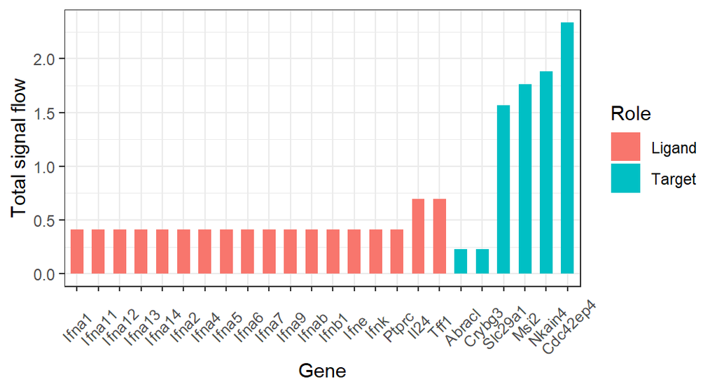

```r
# compute and compare the L-R maxflow
df <- get_LRMaxFlow(exSigNet.new2)
df.TotalFlow <- compare_MaxFlow(df = df)

# bar plot of the signal comparing results
df.TotalFlow %>%
  mutate(Gene = fct_reorder(Gene, TotalFlow* (Role=='Ligand'))) %>%
  mutate(Gene = fct_reorder(Gene, TotalFlow* (Role=='Target'))) %>%
  # mutate(Gene = fct_reorder(Gene, SI* (Type=='Full network'))) %>%
  ggplot(aes(x=Gene, y=TotalFlow,  fill=Role)) +
    geom_bar(stat="identity", alpha=1, width=.6) +
    xlab("Gene") +
    ylab("Total signal flow") +
    theme_bw() +
    theme(axis.text.x = element_text(angle = 45, hjust = 0.5, vjust = 0.5))
```

## Visualize the exSigNet

Heatmap plot

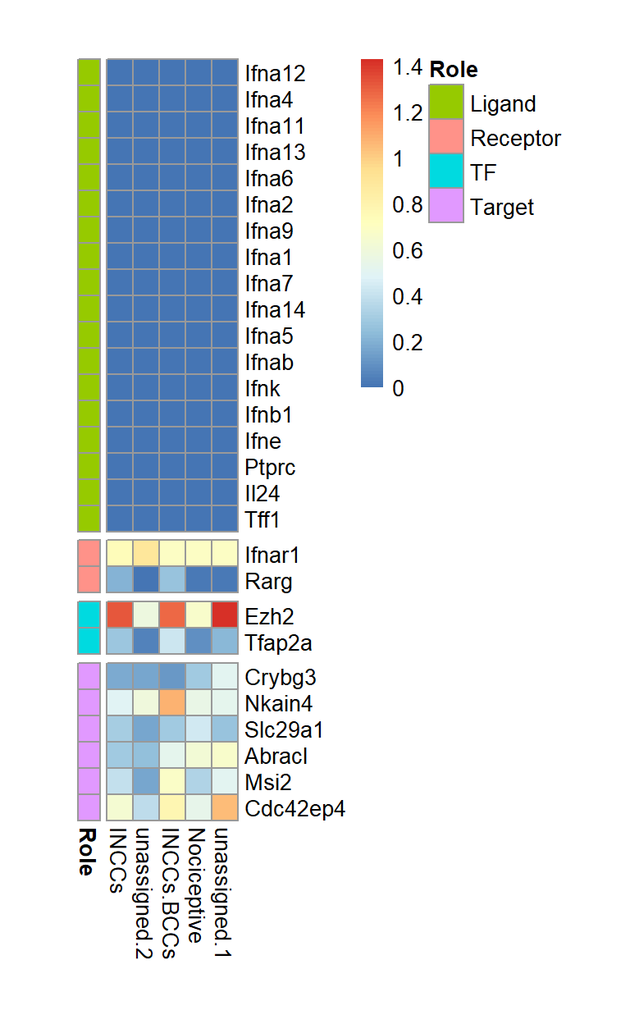

```r
# prepare the dataframe for heatmap plot
exS.new2_exp <- get_AveExp(Gene = exSigNet.new2$Graph.Node$Gene,
           Exp.Data = exp.data,
           Meta.Data = meta.data)

exS.new2_exp.HP <- exS.new2_exp
exS.new2_exp.HP <- exS.new2_exp.HP[, -1]
row.names(exS.new2_exp.HP) <- exS.new2_exp$Gene

## heatmap plot
annotation_row <- data.frame(Role = exSigNet.new2$Graph.Node$Role)
row.names(annotation_row) <- row.names(exS.new2_exp.HP)

pheatmap(exS.new2_exp.HP,
        cluster_row = FALSE, cluster_cols = FALSE,
        cellwidth = 12, cellheight = 12,
        gaps_row = c(18, 20, 22),
        fontsize_row = 10,
        fontsize_col = 10,
        annotation_row = annotation_row)
```

hierarchy plot

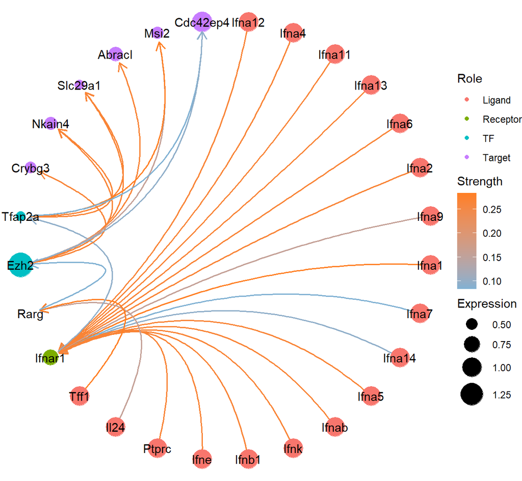

```r
# Graph <- exSigNet.new2
#
# hierarchy <- data.frame(from="origin", to=Graph$Graph.Node$Gene)
# all_leaves <- Graph$Graph.Node$Gene
#
# connect <- data.frame(from = Graph$Graph.Edge$from, to = Graph$Graph.Edge$to)
# connect$value <- Graph$Graph.Edge$Weight
#
# vertices <- data.frame(name = unique(c(as.character(hierarchy$from), as.character(hierarchy$to))),
#                        Expression = c(0, Graph$Graph.Node$Size))
# vertices$node <- c(" ", Graph$Graph.Node$Gene)
# vertices$Role <- c("NA", Graph$Graph.Node$Role)
#
# mygraph <- igraph::graph_from_data_frame( hierarchy, vertices=vertices )
#
# from <- match( connect$from, vertices$name)
# to <- match( connect$to, vertices$name)
# weight <- connect$value


# hierarchy plot
exSigNet.new2_plot <- get_readyforplot(Graph = exSigNet.new2)

ggraph(exSigNet.new2_plot[[1]], layout = 'dendrogram', circular = TRUE) +
  geom_node_point(aes(filter = leaf, x=x, y=y, colour=Role, size=Expression)) +
  theme_void() +
  geom_conn_bundle(data = get_con(from = exSigNet.new2_plot[[2]]$from,
                                  to = exSigNet.new2_plot[[2]]$to,
                                  Strength = exSigNet.new2_plot[[2]]$weight), width = 0.7, aes(colour=Strength),
                   arrow = arrow(length = unit(3, 'mm')), start_cap = circle(3, 'mm'), end_cap = circle(3, 'mm')) +
  scale_edge_color_continuous(low="#80b1d3", high="#FF7F24")+
  geom_node_text(aes(label = node)) +
  scale_size_continuous( range = c(0.1,10) )
```

## Evaluate GO analysis results

```r
library(org.Mm.eg.db)
# library(org.Dr.eg.db)
# library(org.Hs.eg.db)
```

```r
# GO analysis and evaluate top 5 GO terms
GO.exSigNet.new2 <- get_EnrichAnalysis(Graph = exSigNet.new2,
                               OrgDb = org.Mm.eg.db,
                               Number.of.Terms = 5,
                               ont = "BP",
                               pvalueCutoff = 0.05,
                               qvalueCutoff = 0.2)
GO.exSigNet.new2
```

```
#> $`GO analysis results`
#> #
#> # over-representation test
#> #
#> #...@organism     Mus musculus
#> #...@ontology     BP
#> #...@keytype      ENTREZID
#> #...@gene     chr [1:28] "242519" "15967" "15964" "230396" "15969" "15965" "15972" ...
#> #...pvalues adjusted by 'BH' with cutoff <0.05
#> #...58 enriched terms found
#> 'data.frame':    58 obs. of  9 variables:
#>  $ ID         : chr  "GO:0042501" "GO:0033141" "GO:0033139" "GO:0002323" ...
#>  $ Description: chr  "serine phosphorylation of STAT protein" "positive regulation of peptidyl-serine phosphorylation of STAT protein" "regulation of peptidyl-serine phosphorylation of STAT protein" "natural killer cell activation involved in immune response" ...
#>  $ GeneRatio  : chr  "16/28" "15/28" "15/28" "15/28" ...
#>  $ BgRatio    : chr  "37/29008" "29/29008" "32/29008" "43/29008" ...
#>  $ pvalue     : num  3.25e-41 4.37e-40 3.19e-39 8.49e-37 1.66e-34 ...
#>  $ p.adjust   : num  2.41e-38 1.62e-37 7.87e-37 1.57e-34 2.46e-32 ...
#>  $ qvalue     : num  1.55e-38 1.04e-37 5.06e-37 1.01e-34 1.58e-32 ...
#>  $ geneID     : chr  "242519/15967/15964/230396/15969/15965/15972/15962/15970/404549/15968/15974/387510/15977/230405/93672" "242519/15967/15964/230396/15969/15965/15972/15962/15970/404549/15968/15974/387510/15977/230405" "242519/15967/15964/230396/15969/15965/15972/15962/15970/404549/15968/15974/…
#>  $ Count      : int  16 15 15 15 15 17 15 17 16 16 ...
#> #...Citation
#>  T Wu, E Hu, S Xu, M Chen, P Guo, Z Dai, T Feng, L Zhou, W Tang, L Zhan, X Fu, S Liu, X Bo, and G Yu.
#>  clusterProfiler 4.0: A universal enrichment tool for interpreting omics data.
#>  The Innovation. 2021, 2(3):100141
#>
#>
#> $Evaluation
#>             Node.Pct   Exp.Pct
#> GO:0042501 0.5357143 0.6110001
#> GO:0033141 0.5357143 0.6110001
#> GO:0033139 0.5357143 0.6110001
#> GO:0002323 0.5357143 0.6110001
#> GO:0043330 0.5714286 0.6517334
#>                                                                           GO.Name
#> GO:0042501                                 serine phosphorylation of STAT protein
#> GO:0033141 positive regulation of peptidyl-serine phosphorylation of STAT protein
#> GO:0033139          regulation of peptidyl-serine phosphorylation of STAT protein
#> GO:0002323             natural killer cell activation involved in immune response
#> GO:0043330                                            response to exogenous dsRNA
```

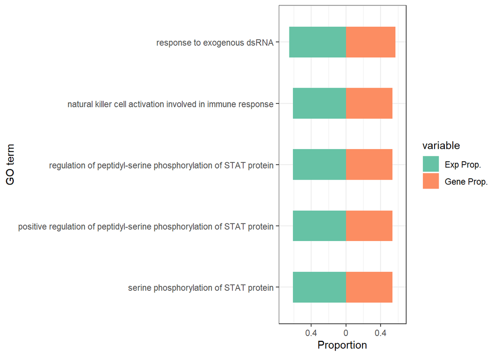

```r
# prepare for bar plot
GO.df <- GO.exSigNet.new2[[2]]
GO.df.1 <- data.frame(GO.term = rownames(GO.df), variable = "Gene Prop.", value = GO.df$Node.Pct, GO.name = GO.df$GO.Name)
GO.df.2 <- data.frame(GO.term = rownames(GO.df), variable = "Exp Prop.", value = GO.df$Exp.Pct, GO.name = GO.df$GO.Name)
GO.df.3 <- rbind(GO.df.1, GO.df.2)

ggplot(GO.df.3, aes(
                x = factor(GO.name, levels = unique(GO.name)),
                y = ifelse(variable == "Gene Prop.", value, -value),  fill = variable)) +
  geom_bar(stat = 'identity', width=0.5)+
  scale_fill_brewer(palette = 'Set2')+
  coord_flip()+
  scale_y_continuous(
    labels = abs,
    expand = expansion(mult = c(0.1, 0.1))) +
    ylab("Proportion") +
    xlab("GO term") +
    theme_bw()
```